# Repeated Measures Correlation (rmcorr): few notes

In this post, we use the Repeated Measures Correlation (*rmcorr*) approach to quantify association between two continuous measures recorded multiple times per study subject.

I recently learned about the *rmcorr* approach and explored it with a view of applying in one of the current projects. Here, I highlight my key notes from how the *rmcorr* works, and I point to a few cases where I expect that *rmcorr* may be not an ideal choice to quantify the association.

This post is to encourage caution when considering one’s data fit for methods selection and results interpretation, and also to serve for me as a handy reference if needed in the future.

## Repeated Measures Correlation

The Bakdash et al. (2017) paper [Repeated Measures Correlation](https://www.frontiersin.org/articles/10.3389/fpsyg.2017.00456/full) discusses within-participants correlation to analyze the common intra-individual association for paired repeated measures. The paper provides background information, methods description, R package reference, and discussion on tradeoffs with *rmcorr* as compared to multilevel modeling.

### Method

In short, *rmcorr*:

- Is based on ANCOVA analysis: it considers a subject as a factor-level variable to remove between-person variation. ANCOVA model is set to estimate subjects’ common regression slope $\beta$:
  $$\begin{aligned}
  \text {Measure1}_{ij}=\overline{\text {Measure1}}_{j}+\text {Participant}_{j} +\beta\left(\text {Measure2}_{ij}-\overline{\text {Measure2}}_{j}\right)+\varepsilon_{ij}.
  \end{aligned}$$
- The rmcorr correlation coefficient is calculated using sums of squares for the Measure and for the error from the above ANCOVA model:
  $$\begin{aligned}
  r_{rm}=\sqrt{\frac{SS_{\text{Measure}}}{SS_{\text {Measure}}+SS_{\text {Error}}}}
  \end{aligned}$$
  and its sign is determined by the sign (positive vs. negative) of estimated $\beta$.
- It has a nice, intuitive interpretation.
- Authors argue is “comparable to linear multilevel model (*LMM*) with random intercept only and a fixed effect”.

### Key notes

My key notes on *rmcorr*:

- *rmcorr* does not allow for slope variation by subject,
- *rmcorr* does not utilize any of *LMM*’s partial-pooling idea (i.e., where for subjects with a relatively smaller number of observations, their estimates are “shrunk” closer to the overall population average);

and hence, to my judgement, *rmcorr* may be not an ideal choice to quantify the association when:

- when the effect slope varies between subjects,
- when the number of observations varies between subjects (e.g., varies between 2-10),
- when there are influential observation(s) (e.g., subject(s) with wide $x$ values range).

## Scenarios

To illustrate the above notes, 8 simple data scenarios are considered.

- In each scenario, data on N = 20 subjects with 2 continuous variables ($x$, $y$), recorded at multiple occasions for each subject, are simulated.
- The scenarios differ in true data-generating model that is assumed in a scenario.
- For each scenario, 1 data set is used and results from applying 2 approaches are shown:
  - 1. left plot: *rmcorr* with an estimate of “repeated measures correlation”,
  - 2. right plot: *LMM* fit with an estimate of fixed effect slope.
- For all scenarios, left plot points same as right plot points (the same data used for 2 approaches).
- For all scenarios, population-level effect $x$ on $y$ was assumed to be equal $2.0$.
- For all scenarios, *LMM* assumes random intercept and random slope for $x$, and a fixed effect for $x$.

**(Click to see R code shared for all simulations.)**

```r
library(tidyverse)
library(lme4)
library(lmerTest)
library(rmcorr)
library(MASS)

# define simulation parameters
# number of subjects
M <- 20
# number of repeated measures per subjects (for all except last two scenarios)
k <- 5

#' Function to apply two approaches to `dat` data set:
#' (1) rmcorr with an estimate of "repeated measures correlation",
#' (2) LMM fit with an estimate of fixed effect slope
est_and_plot <- function(dat){
  # approach 1
  rmcorr_out <- rmcorr(subj_id, x, y, dat)
  plt_label <- paste0("r = ", round(rmcorr_out$r, 3), " (95% CI: [", paste0(round(rmcorr_out$CI, 3), collapse = ", "), "])")
  par(mar = rep(2, 4))
  plot(rmcorr_out, main = plt_label)

  # approach 2
  lmm_out <- lmer(y ~ x + (1 + x | subj_id), data = dat)
  conf_est <- summary(lmm_out)$coef[2, 1]
  conf_out <- as.vector(confint(lmm_out, parm = "x"))
  plt_label <- paste0("beta = ", round(conf_est, 3), " (95% CI: [", paste0(round(conf_out, 3), collapse = ", "), "])")
  dat$mu <- getME(lmm_out, "mu")[1 : nrow(dat)]
  plt <-
    ggplot(dat, aes(x = x, y = y, color = subj_id, group = subj_id)) +
    # geom_line(color = "black") +
    geom_line(aes(x = x, y = mu), size = 0.3) +
    geom_point() +
    theme_classic(base_size = 12) +
    theme(
      legend.position = "none",
    )  +
    labs(x = "x", y = "y", title = plt_label)
  plot(plt)
}
```

### Scenario 1a

Data-generating model:

- random intercept only
- small residual error

**(Click to see R code.)**

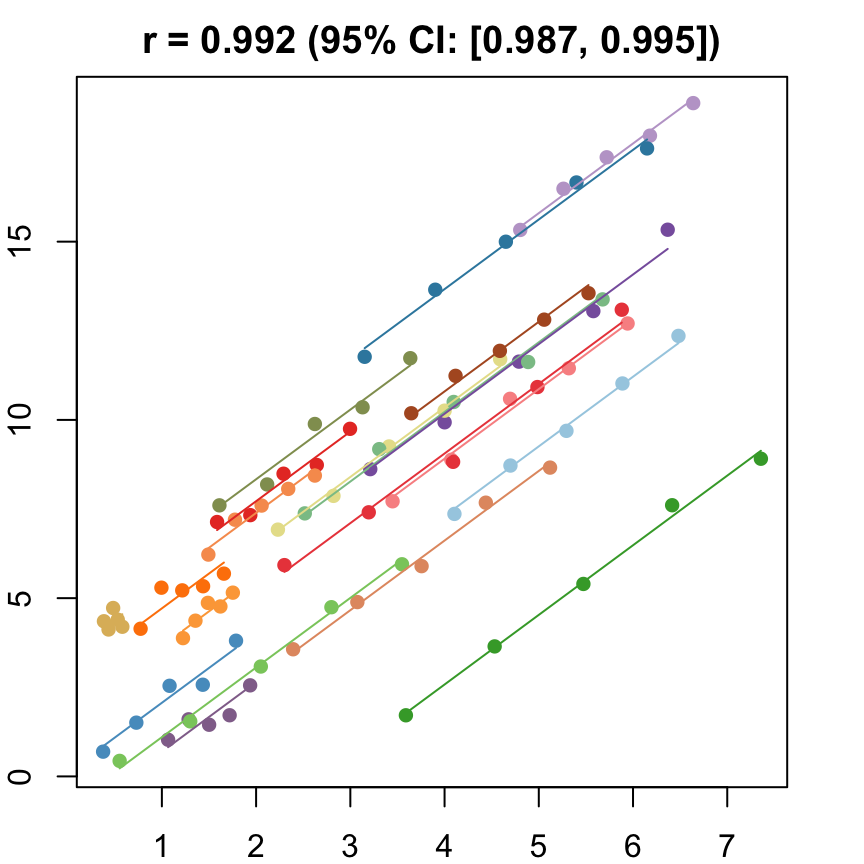

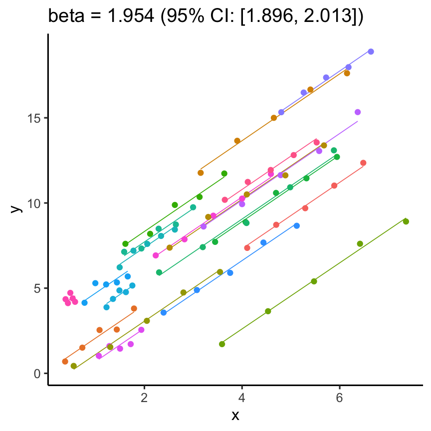

```r
set.seed(1)
eps_sd <- 0.25
alpha = 1
beta = 2
ai = rnorm(M, mean = 0, sd = 3)
bi = rnorm(M, mean = 0, sd = 0)

subj_id_vec <- numeric()
x_vec <- numeric()
y_vec <- numeric()
for (i in 1 : M){ # i <- 2
  x_a <- runif(1, 0, 5)
  x_b <- x_a + 2 + rnorm(1)
  x <- seq(x_a, x_b, length.out = k)
  eps <- rnorm(k, mean = 0, sd = eps_sd)
  y <- (alpha + ai[i]) + (beta + bi[i]) * x + eps
  subj_id_vec <- c(subj_id_vec, rep(paste0("subj_id_", i), k))
  x_vec <- c(x_vec, x)
  y_vec <- c(y_vec, y)
}
dat <- data.frame(subj_id = factor(subj_id_vec), x = x_vec, y = y_vec)
est_and_plot(dat)
```

### Scenario 1b

Data-generating model:

- random intercept only
- large residual error

**(Click to see R code.)**

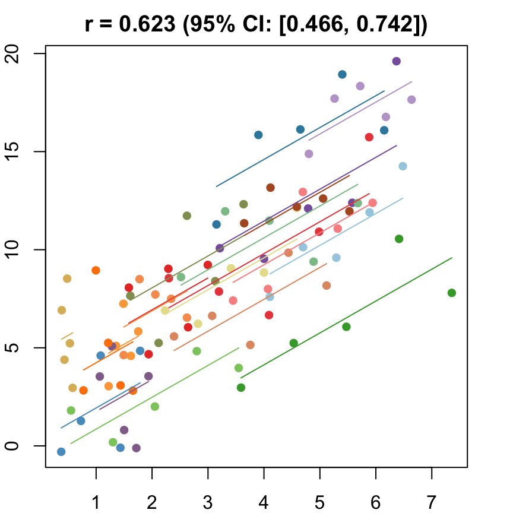

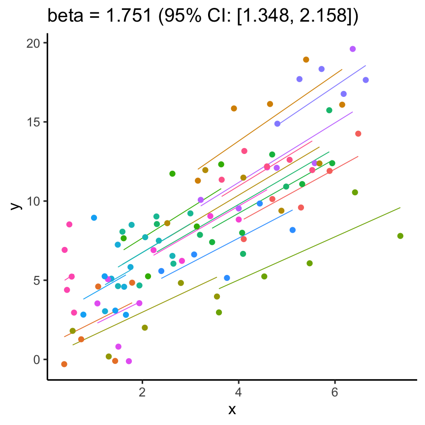

```r
set.seed(1)
eps_sd <- 2
alpha = 1
beta = 2
ai = rnorm(M, mean = 0, sd = 3)
bi = rnorm(M, mean = 0, sd = 0)

subj_id_vec <- numeric()
x_vec <- numeric()
y_vec <- numeric()
for (i in 1 : M){ # i <- 2
  x_a <- runif(1, 0, 5)
  x_b <- x_a + 2 + rnorm(1)
  x <- seq(x_a, x_b, length.out = k)
  eps <- rnorm(k, mean = 0, sd = eps_sd)
  y <- (alpha + ai[i]) + (beta + bi[i]) * x + eps
  subj_id_vec <- c(subj_id_vec, rep(paste0("subj_id_", i), k))
  x_vec <- c(x_vec, x)
  y_vec <- c(y_vec, y)
}
dat <- data.frame(subj_id = factor(subj_id_vec), x = x_vec, y = y_vec)
est_and_plot(dat)
```

### Scenario 2a

Data-generating model:

- random intercept and random slope (uncorrelated)
- small residual error

**(Click to see R code.)**

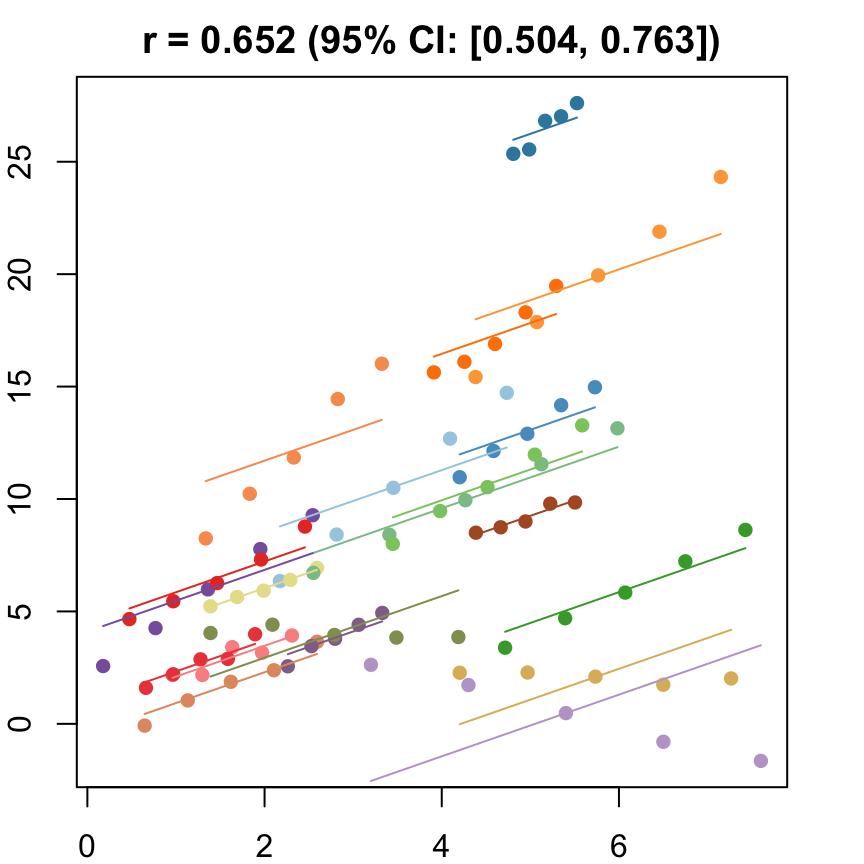

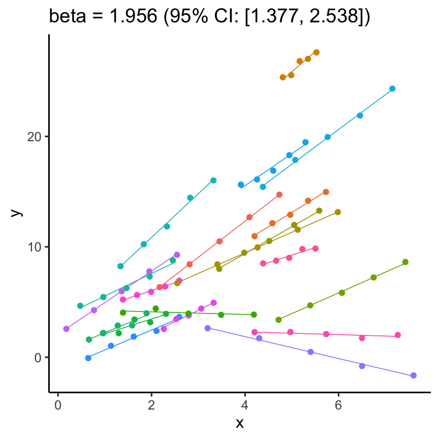

```r
set.seed(1)
eps_sd <- 0.25
alpha = 1
beta = 2
ai = rnorm(M, mean = 0, sd = 3)
bi = rnorm(M, mean = 0, sd = 1.5)

subj_id_vec <- numeric()
x_vec <- numeric()
y_vec <- numeric()
for (i in 1 : M){ # i <- 2
  x_a <- runif(1, 0, 5)
  x_b <- x_a + 2 + rnorm(1)
  x <- seq(x_a, x_b, length.out = k)
  eps <- rnorm(k, mean = 0, sd = eps_sd)
  y <- (alpha + ai[i]) + (beta + bi[i]) * x + eps
  subj_id_vec <- c(subj_id_vec, rep(paste0("subj_id_", i), k))
  x_vec <- c(x_vec, x)
  y_vec <- c(y_vec, y)
}
dat <- data.frame(subj_id = factor(subj_id_vec), x = x_vec, y = y_vec)
est_and_plot(dat)
```

### Scenario 2b

Data-generating model:

- random intercept and random slope (uncorrelated)
- large residual error

**(Click to see R code.)**

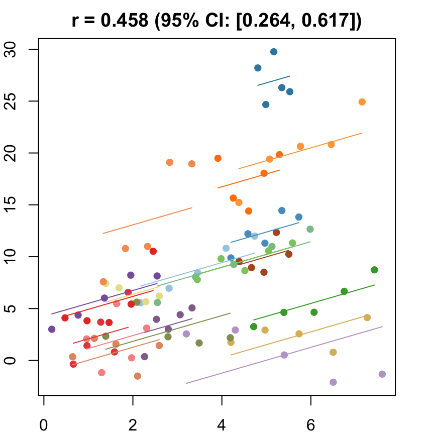

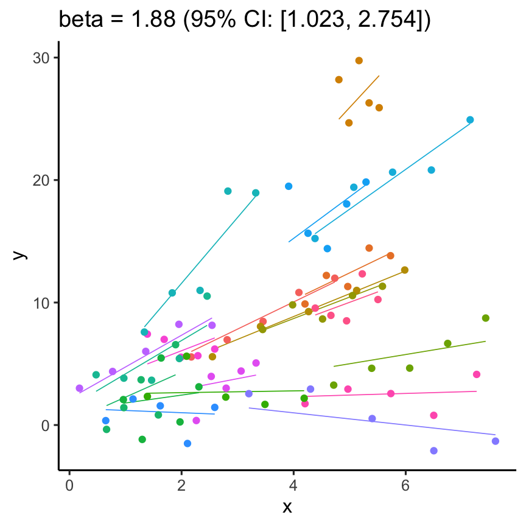

```r
set.seed(1)
eps_sd <- 2
alpha = 1
beta = 2
ai = rnorm(M, mean = 0, sd = 3)
bi = rnorm(M, mean = 0, sd = 1.5)

subj_id_vec <- numeric()
x_vec <- numeric()
y_vec <- numeric()
for (i in 1 : M){ # i <- 2
  x_a <- runif(1, 0, 5)
  x_b <- x_a + 2 + rnorm(1)
  x <- seq(x_a, x_b, length.out = k)
  eps <- rnorm(k, mean = 0, sd = eps_sd)
  y <- (alpha + ai[i]) + (beta + bi[i]) * x + eps
  subj_id_vec <- c(subj_id_vec, rep(paste0("subj_id_", i), k))
  x_vec <- c(x_vec, x)
  y_vec <- c(y_vec, y)
}
dat <- data.frame(subj_id = factor(subj_id_vec), x = x_vec, y = y_vec)
est_and_plot(dat)
```

### Scenario 3a

Data-generating model:

- random intercept and random slope (uncorrelated)
- small residual error
- add one influential observation (wide x-axis range, simulate 0 $x$ effect on $y$ for that subject)

**(Click to see R code.)**

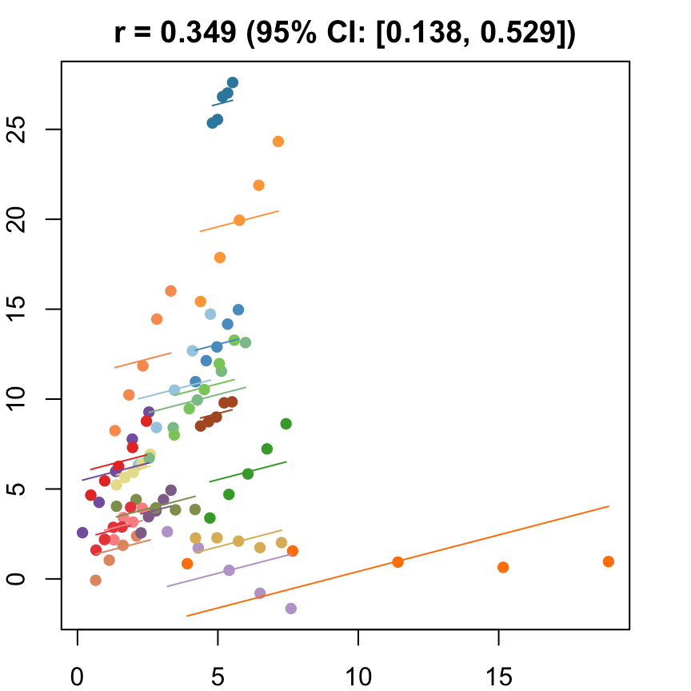

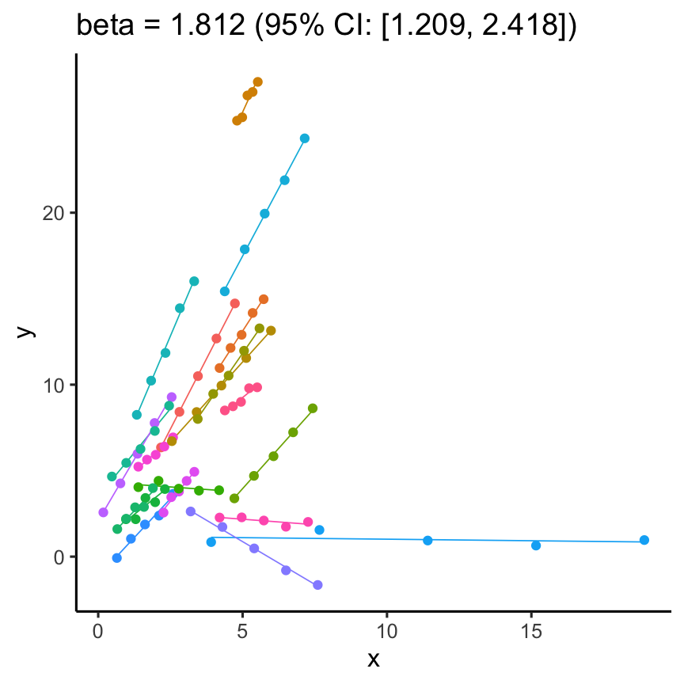

```r
set.seed(1)
eps_sd <- 0.25
alpha = 1
beta = 2
ai = rnorm(M, mean = 0, sd = 3)
bi = rnorm(M, mean = 0, sd = 1.5)

subj_id_vec <- numeric()
x_vec <- numeric()
y_vec <- numeric()
for (i in 1 : (M-1)){ # i <- 2
  x_a <- runif(1, 0, 5)
  x_b <- x_a + 2 + rnorm(1)
  x <- seq(x_a, x_b, length.out = k)
  eps <- rnorm(k, mean = 0, sd = eps_sd)
  y <- (alpha + ai[i]) + (beta + bi[i]) * x + eps
  subj_id_vec <- c(subj_id_vec, rep(paste0("subj_id_", i), k))
  x_vec <- c(x_vec, x)
  y_vec <- c(y_vec, y)
}
i <- M
x_a <- runif(1, 0, 5)
x_b <- x_a + 15
x <- seq(x_a, x_b, length.out = k)
eps <- rnorm(k, mean = 0, sd = eps_sd)
# y <- (alpha + ai[i]) + rep(0, k) + eps
y <- alpha + rep(0, k) + eps
subj_id_vec <- c(subj_id_vec, rep(paste0("subj_id_", i), k))
x_vec <- c(x_vec, x)
y_vec <- c(y_vec, y)
dat <- data.frame(subj_id = factor(subj_id_vec), x = x_vec, y = y_vec)
est_and_plot(dat)
```

### Scenario 3b

Data-generating model:

- random intercept and random slope (uncorrelated)
- large residual error
- add one influential observation (wide x-axis range, simulate 0 $x$ effect on $y$ for that subject)

**(Click to see R code.)**

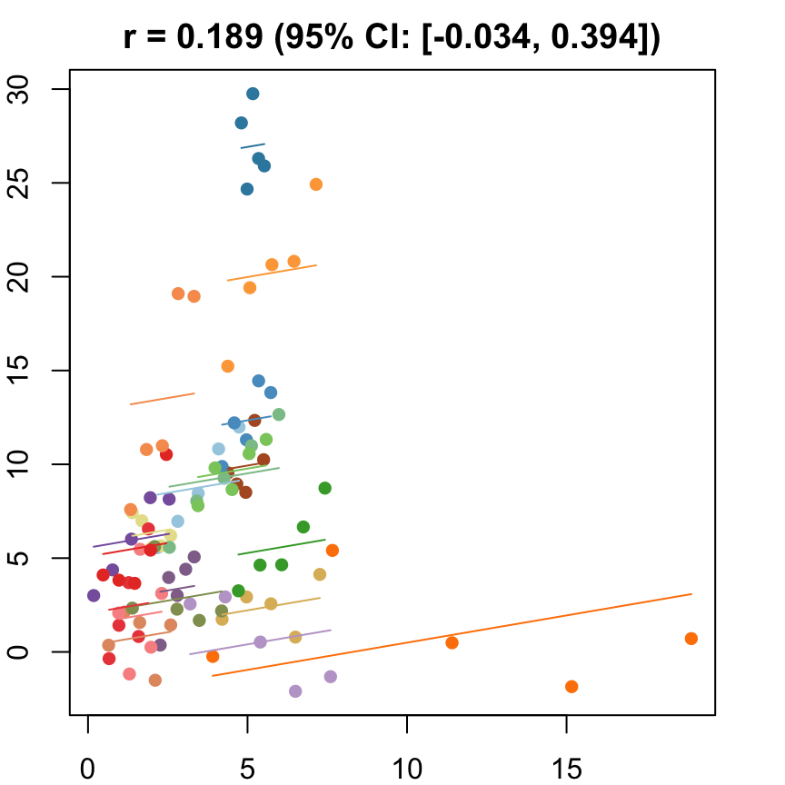

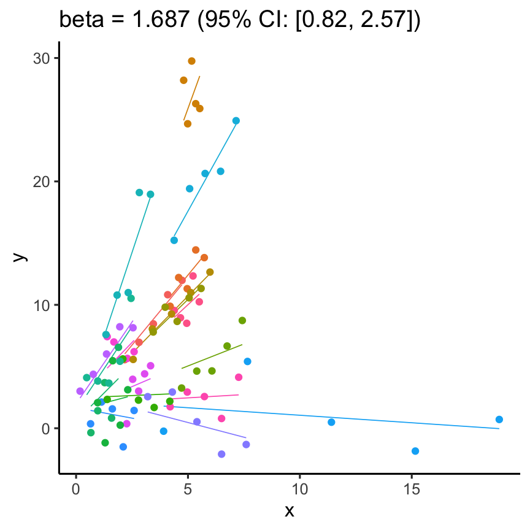

```r
set.seed(1)
eps_sd <- 2
alpha = 1
beta = 2
ai = rnorm(M, mean = 0, sd = 3)
bi = rnorm(M, mean = 0, sd = 1.5)

subj_id_vec <- numeric()
x_vec <- numeric()
y_vec <- numeric()
for (i in 1 : (M-1)){ # i <- 2
  x_a <- runif(1, 0, 5)
  x_b <- x_a + 2 + rnorm(1)
  x <- seq(x_a, x_b, length.out = k)
  eps <- rnorm(k, mean = 0, sd = eps_sd)
  y <- (alpha + ai[i]) + (beta + bi[i]) * x + eps
  subj_id_vec <- c(subj_id_vec, rep(paste0("subj_id_", i), k))
  x_vec <- c(x_vec, x)
  y_vec <- c(y_vec, y)
}
i <- M
x_a <- runif(1, 0, 5)
x_b <- x_a + 15
x <- seq(x_a, x_b, length.out = k)
eps <- rnorm(k, mean = 0, sd = eps_sd)
# y <- (alpha + ai[i]) + rep(0, k) + eps
y <- (alpha + 0) + rep(0, k) + eps
subj_id_vec <- c(subj_id_vec, rep(paste0("subj_id_", i), k))
x_vec <- c(x_vec, x)
y_vec <- c(y_vec, y)
dat <- data.frame(subj_id = factor(subj_id_vec), x = x_vec, y = y_vec)
est_and_plot(dat)
```

### Scenario 4a

Data-generating model:

- random intercept and random slope (uncorrelated)
- small residual error
- various number (between 2 and 8) of observations per subject

**(Click to see R code.)**

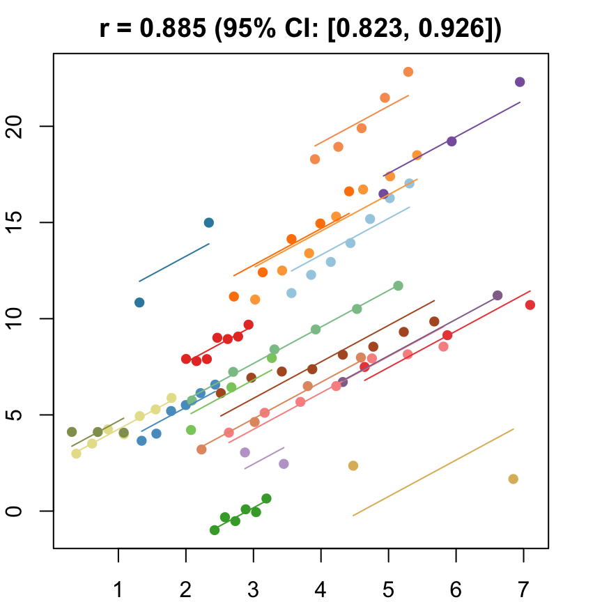

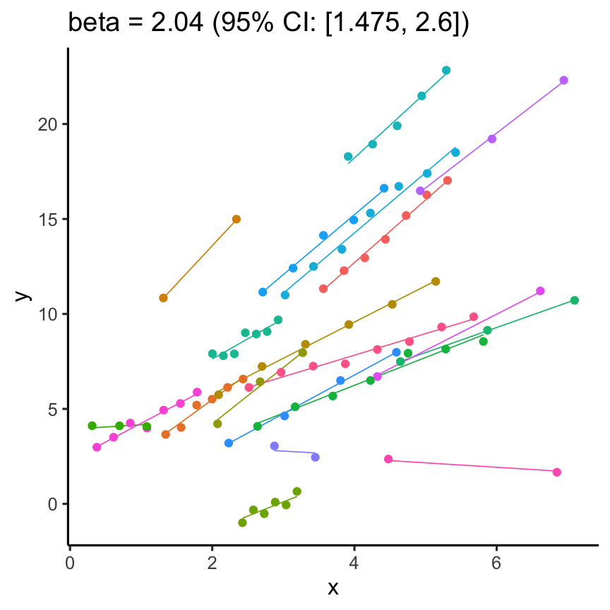

```r
set.seed(1)
eps_sd <- 0.25
alpha = 1
beta = 2
ai = rnorm(M, mean = 0, sd = 3)
bi = rnorm(M, mean = 0, sd = 1.5)

subj_id_vec <- numeric()
x_vec <- numeric()
y_vec <- numeric()
for (i in 1 : M){ # i <- 2
  k_i <- sample(2 : 8, 1)
  x_a <- runif(1, 0, 5)
  x_b <- x_a + 2 + rnorm(1)
  x <- seq(x_a, x_b, length.out = k_i)
  eps <- rnorm(k_i, mean = 0, sd = eps_sd)
  y <- (alpha + ai[i]) + (beta + bi[i]) * x + eps
  subj_id_vec <- c(subj_id_vec, rep(paste0("subj_id_", i), k_i))
  x_vec <- c(x_vec, x)
  y_vec <- c(y_vec, y)
}
dat <- data.frame(subj_id = factor(subj_id_vec), x = x_vec, y = y_vec)
est_and_plot(dat)
```

### Scenario 4b

Data-generating model:

- random intercept and random slope (uncorrelated)
- large residual error
- various number (between 2 and 8) of observations per subject

**(Click to see R code.)**

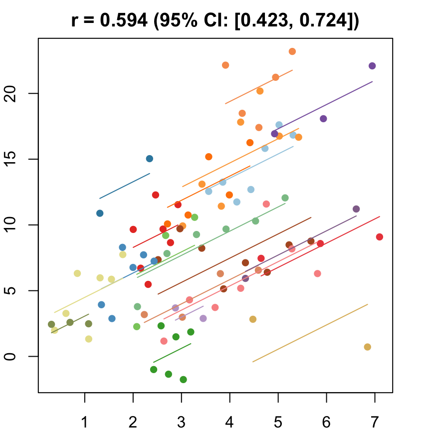

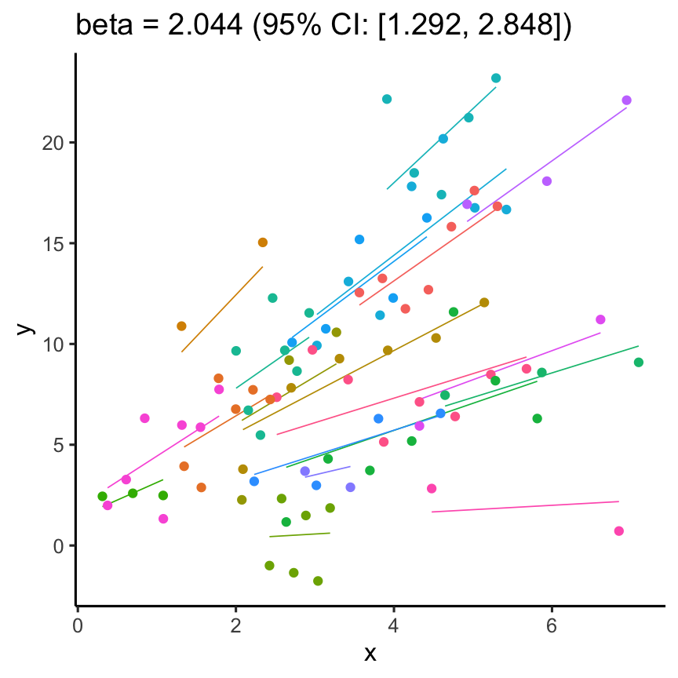

```r
set.seed(1)
eps_sd <- 2
alpha = 1
beta = 2
ai = rnorm(M, mean = 0, sd = 3)
bi = rnorm(M, mean = 0, sd = 1.5)

subj_id_vec <- numeric()
x_vec <- numeric()
y_vec <- numeric()
for (i in 1 : M){ # i <- 2
  k_i <- sample(2 : 8, 1)
  x_a <- runif(1, 0, 5)
  x_b <- x_a + 2 + rnorm(1)
  x <- seq(x_a, x_b, length.out = k_i)
  eps <- rnorm(k_i, mean = 0, sd = eps_sd)
  y <- (alpha + ai[i]) + (beta + bi[i]) * x + eps
  subj_id_vec <- c(subj_id_vec, rep(paste0("subj_id_", i), k_i))
  x_vec <- c(x_vec, x)
  y_vec <- c(y_vec, y)
}
dat <- data.frame(subj_id = factor(subj_id_vec), x = x_vec, y = y_vec)
est_and_plot(dat)
```

## Observations

- When the “true” effect slope varies between subjects, the estimated *rmcorr* correlation, $r_{rm}$, might be tanking. See Scenario 2a ($r_{rm}=0.652$) and 2b ($r_{rm}=0.458$) where data-generating model assumed varying slope, and compare with Scenario 1a ($r_{rm}=0.992$) and 1b ($r_{rm}=0.623$) where data-generating model assumed the same population-effect as 2a and 2b but no varying slope.
- In presence of influential observation, the estimated *rmcorr* correlation, $r_{rm}$, appear to be prone to be largely affected. See Scenario 3a and 3b where influential observation was added (data for one subject, assumed wide x-axis range, simulate 0 $x$ effect on $y$ for that subject). Compare scenario 2a and 3a ($r_{rm}=0.652$ => $r_{rm}=0.349$) and Scenario 2b and 3b ($r_{rm}=0.458$ => $r_{rm}=0.189$) where data-generating models within these pairs differ only by how data for that one subject were simulated.
- When number of observations varies between subjects (and especially when it is small for some), due to lack of partial-pooling mechanism, I expect *rmcorr* correlation results might be unstable too. See Scenario 4a and 4b where various number (between 2 and 8) of observations per subject was assumed. Compare scenario 2a and 4a ($r_{rm}=0.652$ => $r_{rm}=0.885$) and Scenario 2b and 4b ($r_{rm}=0.458$ => $r_{rm}=0.594$) which data-generating models only differ by assuming fixed or variate number of observations per subject (while the average number of observations per subject is set the same).

## Conclusion

In conclusion: *rmcorr* is IMO a very interesting method with neat “repeated measures correlation interpretation”. However, in some data scenarios demonstrated above (e.g., if true effect slope varies between subjects) the correlation estmated by *rmcorr* might be not an ideal choice to quantify the association between two measures.